# Krystal Ball: Hotel Bar Inventory Forecasting & Par Level Recommendation System

**Goal.** Turn bottle-level transaction logs from multiple hotel bars into daily consumption series, forecast future demand, calculate a dynamic Par Level (reorder target) per bar/brand, and backtest that policy against a naive baseline via a discrete-event inventory simulation.

**Notebook sections**

1. Data Understanding & Preprocessing
2. Exploratory Data Analysis (ABC classification, seasonality, stockout audit)
3. Demand Forecasting (Baseline vs Holt-Winters vs Random Forest)
4. Par Level & Safety Stock Calculation
5. Inventory Simulation Engine (Naive vs Recommended policy)
6. Findings & Recommendations

> **Note on the data.** No transaction log was supplied with this assignment brief, so this notebook generates a realistic synthetic dataset that matches the required schema (`Date Time Served`, `Bar Name`, `Brand Name`, `Opening Balance`, `Purchase`, `Consumed`, `Closing Balance`) across 4 bars x 10 brands x 210 days, with weekly seasonality, a mild upward trend, and intermittent slow-movers. **To use real data**, drop your own `bar_inventory_data.csv` into `data/raw/` with the same column names and skip the "Generate synthetic data" cell — everything downstream is written generically and will run unchanged on real transaction logs with that schema.

```python
import warnings
warnings.filterwarnings("ignore")

import numpy as np
import pandas as pd
import matplotlib.pyplot as plt
import seaborn as sns

from statsmodels.tsa.holtwinters import ExponentialSmoothing
from sklearn.ensemble import RandomForestRegressor

%matplotlib inline
sns.set_style("whitegrid")
plt.rcParams["figure.figsize"] = (11, 4.5)
pd.set_option("display.width", 140)

RAW_PATH  = "../data/raw/bar_inventory_data.csv"
PROC_PATH = "../data/processed/daily_bar_consumption.csv"

LEAD_TIME_DAYS = 2      # supplier lead time, in days
SERVICE_Z      = 1.645  # 95% service level (use 2.326 for 99%)
```

## 0. Generate synthetic data (skip this cell if you have a real `bar_inventory_data.csv`)

Simulates realistic bottle-ledger transactions: pours throughout the evening (weighted randomly to sum to a day's total demand, itself driven by weekday/weekend seasonality, a mild upward trend, and per-brand "velocity"), plus periodic supplier deliveries. Every row is constructed to satisfy the inventory conservation identity:

`Closing Balance = Opening Balance + Purchase − Consumed`

```python
rng = np.random.default_rng(42)

BARS = {
    "Skyline Rooftop Bar": 1.35,
    "Poolside Bar":        1.10,
    "Lobby Lounge Bar":    0.80,
    "Sports Bar":          1.00,
}

# brand -> (velocity class, base daily mean ml, restock qty ml, restock cycle days)
BRANDS = {
    "Grey Goose Vodka":      ("A", 2600, 12000, 2),
    "Absolut Vodka":         ("A", 2200, 12000, 2),
    "Jack Daniel's Whiskey": ("A", 2400, 12000, 2),
    "Johnnie Walker Black":  ("B", 1400,  9000, 3),
    "Bacardi Rum":           ("B", 1100,  9000, 3),
    "Jose Cuervo Tequila":   ("B",  900,  9000, 3),
    "Heineken Beer":         ("A", 3000, 15000, 2),
    "Corona Beer":           ("A", 2800, 15000, 2),
    "Aperol":                ("C",  350,  6000, 5),
    "Campari":               ("C",  300,  6000, 5),
}

from datetime import datetime, timedelta
START_DATE, N_DAYS = datetime(2025, 1, 1), 210
rows = []

for bar, bar_mult in BARS.items():
    for brand, (velocity, base_mean, restock_qty, restock_cycle) in BRANDS.items():
        stock = restock_qty * 1.5
        next_restock_offset = int(rng.integers(0, restock_cycle))

        for day_idx in range(N_DAYS):
            date = START_DATE + timedelta(days=day_idx)
            dow = date.weekday()
            dow_factor = {0: 0.75, 1: 0.80, 2: 0.90, 3: 1.05, 4: 1.45, 5: 1.55, 6: 1.15}[dow]
            trend_factor = 1.0 + 0.15 * (day_idx / N_DAYS)

            sell_today = not (velocity == "C" and rng.random() < 0.35)
            daily_mean = base_mean * bar_mult * dow_factor * trend_factor
            daily_demand = max(0.0, rng.normal(daily_mean, daily_mean * 0.25)) if sell_today else 0.0

            if day_idx == 0 or (day_idx - next_restock_offset) % restock_cycle == 0:
                purchase_today = restock_qty * rng.uniform(0.9, 1.1)
                ts = date.replace(hour=10, minute=int(rng.integers(0, 59)))
                opening = stock
                closing = opening + purchase_today
                rows.append({"Date Time Served": ts, "Bar Name": bar, "Brand Name": brand,
                             "Opening Balance (ml)": round(opening, 1), "Purchase (ml)": round(purchase_today, 1),
                             "Consumed (ml)": 0.0, "Closing Balance (ml)": round(closing, 1)})
                stock = closing

            if daily_demand > 0:
                n_tx = int(rng.integers(3, 14))
                weights = rng.dirichlet(np.ones(n_tx))
                pour_amounts = np.round(daily_demand * weights, 1)
                hours = np.sort(rng.uniform(11, 23.98, size=n_tx))
                for pour_ml, hr in zip(pour_amounts, hours):
                    h, m = int(hr), int((hr - int(hr)) * 60)
                    ts = date.replace(hour=min(h, 23), minute=min(m, 59))
                    opening = stock
                    actual_consumed = min(pour_ml, opening)
                    closing = opening - actual_consumed
                    rows.append({"Date Time Served": ts, "Bar Name": bar, "Brand Name": brand,
                                 "Opening Balance (ml)": round(opening, 1), "Purchase (ml)": 0.0,
                                 "Consumed (ml)": round(actual_consumed, 1), "Closing Balance (ml)": round(closing, 1)})
                    stock = closing

synthetic_df = pd.DataFrame(rows).sort_values(["Bar Name", "Brand Name", "Date Time Served"]).reset_index(drop=True)
synthetic_df.to_csv(RAW_PATH, index=False)
print(f"Synthetic transaction log written: {len(synthetic_df):,} rows -> {RAW_PATH}")
synthetic_df.head()
```

```
Synthetic transaction log written: 65,504 rows -> ../data/raw/bar_inventory_data.csv
```

|  | Date Time Served | Bar Name | Brand Name | Opening Balance (ml) | Purchase (ml) | Consumed (ml) | Closing Balance (ml) |
| --- | --- | --- | --- | --- | --- | --- | --- |
| 0 | 2025-01-01 10:04:00 | Lobby Lounge Bar | Absolut Vodka | 18000.0 | 12683.4 | 0.0 | 30683.4 |
| 1 | 2025-01-01 12:24:00 | Lobby Lounge Bar | Absolut Vodka | 30683.4 | 0.0 | 389.2 | 30294.2 |
| 2 | 2025-01-01 13:20:00 | Lobby Lounge Bar | Absolut Vodka | 30294.2 | 0.0 | 88.8 | 30205.4 |
| 3 | 2025-01-01 13:54:00 | Lobby Lounge Bar | Absolut Vodka | 30205.4 | 0.0 | 2.6 | 30202.8 |
| 4 | 2025-01-01 15:13:00 | Lobby Lounge Bar | Absolut Vodka | 30202.8 | 0.0 | 130.3 | 30072.5 |

## 1. Data Understanding & Preprocessing

Steps: parse timestamps, verify the inventory conservation equation, aggregate erratic transactions to a **daily** grain per Bar x Brand, then reindex onto a **complete** date grid so every Bar-Brand pair has an explicit row (including zero-consumption days) — without this, forecasting models never learn true zero-demand periods.

```python
df = pd.read_csv(RAW_PATH)
df["Date Time Served"] = pd.to_datetime(df["Date Time Served"])
df["Date"] = df["Date Time Served"].dt.floor("D")

# --- verify conservation: Closing = Opening + Purchase - Consumed ---
conservation_gap = (df["Opening Balance (ml)"] + df["Purchase (ml)"]
                     - df["Consumed (ml)"] - df["Closing Balance (ml)"]).abs()
assert conservation_gap.max() < 0.2, "Conservation equation violated -- check raw data!"
print(f"Conservation check passed. Max abs discrepancy: {conservation_gap.max():.4f} ml")
print(f"Raw transaction rows: {len(df):,}")
df.head()
```

```
Conservation check passed. Max abs discrepancy: 0.1000 ml
Raw transaction rows: 65,504
```

|  | Date Time Served | Bar Name | Brand Name | Opening Balance (ml) | Purchase (ml) | Consumed (ml) | Closing Balance (ml) | Date |
| --- | --- | --- | --- | --- | --- | --- | --- | --- |
| 0 | 2025-01-01 10:04:00 | Lobby Lounge Bar | Absolut Vodka | 18000.0 | 12683.4 | 0.0 | 30683.4 | 2025-01-01 |
| 1 | 2025-01-01 12:24:00 | Lobby Lounge Bar | Absolut Vodka | 30683.4 | 0.0 | 389.2 | 30294.2 | 2025-01-01 |
| 2 | 2025-01-01 13:20:00 | Lobby Lounge Bar | Absolut Vodka | 30294.2 | 0.0 | 88.8 | 30205.4 | 2025-01-01 |
| 3 | 2025-01-01 13:54:00 | Lobby Lounge Bar | Absolut Vodka | 30205.4 | 0.0 | 2.6 | 30202.8 | 2025-01-01 |
| 4 | 2025-01-01 15:13:00 | Lobby Lounge Bar | Absolut Vodka | 30202.8 | 0.0 | 130.3 | 30072.5 | 2025-01-01 |

```python
# --- aggregate erratic transactions to daily totals per Bar x Brand ---
daily_agg = (
    df.groupby(["Date", "Bar Name", "Brand Name"])
      .agg(**{
          "Consumed (ml)": ("Consumed (ml)", "sum"),
          "Purchase (ml)": ("Purchase (ml)", "sum"),
          "Closing Balance (ml)": ("Closing Balance (ml)", "last"),
      })
      .reset_index()
)

# --- build the complete (Date x Bar x Brand) cartesian grid ---
bars   = daily_agg["Bar Name"].unique()
brands = daily_agg["Brand Name"].unique()
dates  = pd.date_range(daily_agg["Date"].min(), daily_agg["Date"].max(), freq="D")
full_index = pd.MultiIndex.from_product([dates, bars, brands], names=["Date", "Bar Name", "Brand Name"])

daily_ts = daily_agg.set_index(["Date", "Bar Name", "Brand Name"]).reindex(full_index).reset_index()
daily_ts["Consumed (ml)"] = daily_ts["Consumed (ml)"].fillna(0.0)
daily_ts["Purchase (ml)"] = daily_ts["Purchase (ml)"].fillna(0.0)
daily_ts = daily_ts.sort_values(["Bar Name", "Brand Name", "Date"])
daily_ts["Closing Balance (ml)"] = daily_ts.groupby(["Bar Name", "Brand Name"])["Closing Balance (ml)"].ffill()

print(f"Daily grid: {daily_ts.shape[0]:,} rows  "
      f"({len(dates)} days x {len(bars)} bars x {len(brands)} brands = {len(dates)*len(bars)*len(brands):,})")

daily_ts.to_csv(PROC_PATH, index=False)
daily_ts.head()
```

```
Daily grid: 8,400 rows  (210 days x 4 bars x 10 brands = 8,400)
```

|  | Date | Bar Name | Brand Name | Consumed (ml) | Purchase (ml) | Closing Balance (ml) |
| --- | --- | --- | --- | --- | --- | --- |
| 0 | 2025-01-01 | Lobby Lounge Bar | Absolut Vodka | 1652.2 | 12683.4 | 29031.2 |
| 40 | 2025-01-02 | Lobby Lounge Bar | Absolut Vodka | 2657.6 | 11802.5 | 38176.1 |
| 80 | 2025-01-03 | Lobby Lounge Bar | Absolut Vodka | 2553.8 | 0.0 | 35622.3 |
| 120 | 2025-01-04 | Lobby Lounge Bar | Absolut Vodka | 3598.5 | 13026.1 | 45049.9 |
| 160 | 2025-01-05 | Lobby Lounge Bar | Absolut Vodka | 1484.8 | 0.0 | 43565.1 |

## 2. Exploratory Data Analysis

**2.1 ABC velocity classification** — rank brands by total volume consumed and bucket by cumulative share (A: top ~70% of volume, B: next ~20%, C: the long tail). Class A items need the tightest stockout control; Class C items are the overstocking risk.

| Brand Name | Total_Consumed_ml | Cumulative_Share | ABC_Class |
| --- | --- | --- | --- |
| Heineken Beer | 3191578.1 | 0.180260 | A |
| Corona Beer | 2912847.2 | 0.344777 | A |
| Grey Goose Vodka | 2712939.7 | 0.498003 | A |
| Jack Daniel's Whiskey | 2541607.9 | 0.641553 | A |
| Absolut Vodka | 2292333.3 | 0.771023 | B |
| Johnnie Walker Black | 1496055.1 | 0.855520 | B |
| Bacardi Rum | 1172356.1 | 0.921734 | C |
| Jose Cuervo Tequila | 943666.0 | 0.975032 | C |
| Aperol | 238863.0 | 0.988523 | C |
| Campari | 203199.0 | 1.000000 | C |

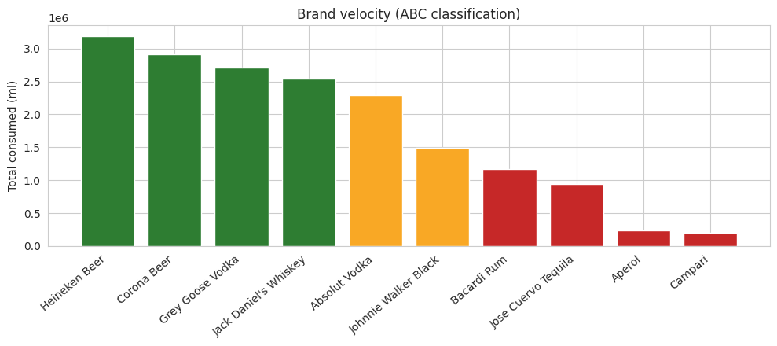

```python
total_by_brand = daily_ts.groupby("Brand Name")["Consumed (ml)"].sum().sort_values(ascending=False)
cum_share = total_by_brand.cumsum() / total_by_brand.sum()
abc_class = cum_share.apply(lambda s: "A" if s <= 0.7 else ("B" if s <= 0.9 else "C"))

abc_table = pd.DataFrame({"Total_Consumed_ml": total_by_brand, "Cumulative_Share": cum_share, "ABC_Class": abc_class})
display(abc_table)

fig, ax = plt.subplots(figsize=(10, 4.5))
colors = abc_table["ABC_Class"].map({"A": "#2E7D32", "B": "#F9A825", "C": "#C62828"})
ax.bar(abc_table.index, abc_table["Total_Consumed_ml"], color=colors)
ax.set_ylabel("Total consumed (ml)")
ax.set_title("Brand velocity (ABC classification)")
plt.xticks(rotation=40, ha="right")
plt.tight_layout()
plt.show()
```

**2.2 Day-of-week seasonality** — confirms the expected Friday/Saturday demand spike used later to justify weekly-seasonal forecasting models.

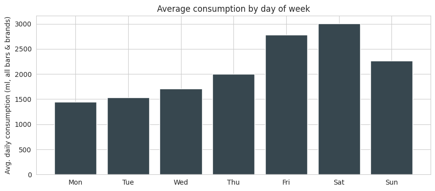

```
Weekend (Fri-Sun) vs weekday average consumption uplift: 60.6%
```

```python
dow_labels = ["Mon", "Tue", "Wed", "Thu", "Fri", "Sat", "Sun"]
dow_avg = daily_ts.groupby(daily_ts["Date"].dt.dayofweek)["Consumed (ml)"].mean()

fig, ax = plt.subplots(figsize=(9, 4))
ax.bar(dow_labels, dow_avg.values, color="#37474F")
ax.set_ylabel("Avg. daily consumption (ml, all bars & brands)")
ax.set_title("Average consumption by day of week")
plt.tight_layout()
plt.show()

print("Weekend (Fri-Sun) vs weekday average consumption uplift:",
      f"{(dow_avg.iloc[[4,5,6]].mean() / dow_avg.iloc[[0,1,2,3]].mean() - 1):.1%}")
```

**2.3 Stockout audit** — flag days where the last recorded closing balance for a Bar-Brand pair hit zero. In this synthetic dataset deliveries are triggered proactively, so observed hard stockouts are rare; the simulation in Section 5 is what actually stress-tests policies against real demand volatility and lets us count *simulated* stockouts under different par-level policies.

```python
stockout_rows = daily_ts[daily_ts["Closing Balance (ml)"] == 0]
print(f"Bar-Brand-days ending at a zero closing balance: {len(stockout_rows)} "
      f"({len(stockout_rows) / len(daily_ts):.2%} of all rows)")
if len(stockout_rows):
    display(stockout_rows.groupby(["Bar Name", "Brand Name"]).size().sort_values(ascending=False).head(10))
```

```
Bar-Brand-days ending at a zero closing balance: 0 (0.00% of all rows)
```

## 3. Demand Forecasting

For **every Bar x Brand series** we fit three candidate models on a temporal 80/20 train/test split (never a randomized k-fold on time series) and keep the best by WAPE:

- **Baseline** — 7-day trailing rolling mean (a naive seasonal-ish baseline)
- **Holt-Winters** — additive exponential smoothing with a 7-day seasonal period
- **Random Forest** — lag (`t-1`, `t-7`, `t-14`), rolling mean/std, and day-of-week features

**WAPE** (`sum(|y - y_hat|) / sum(y)`) is used instead of MAPE because MAPE divides by individual actuals and blows up on the many zero-demand days in this intermittent data.

```python
def make_features(series_df):
    s = series_df.sort_values("Date").reset_index(drop=True)
    s["lag_1"]  = s["Consumed (ml)"].shift(1)
    s["lag_7"]  = s["Consumed (ml)"].shift(7)
    s["lag_14"] = s["Consumed (ml)"].shift(14)
    s["rolling_mean_7"] = s["Consumed (ml)"].shift(1).rolling(7).mean()
    s["rolling_std_7"]  = s["Consumed (ml)"].shift(1).rolling(7).std()
    s["dayofweek"] = s["Date"].dt.dayofweek
    s["is_weekend"] = s["dayofweek"].isin([4, 5, 6]).astype(int)
    return s

def wape(y_true, y_pred):
    y_true, y_pred = np.asarray(y_true), np.asarray(y_pred)
    denom = np.sum(np.abs(y_true))
    return np.sum(np.abs(y_true - y_pred)) / denom if denom > 0 else np.nan

def mae(y_true, y_pred):
    return np.mean(np.abs(np.asarray(y_true) - np.asarray(y_pred)))

FEATURE_COLS = ["lag_1", "lag_7", "lag_14", "rolling_mean_7", "rolling_std_7", "dayofweek", "is_weekend"]
```

```python
results, forecast_store = [], {}

for (bar, brand), g in daily_ts.groupby(["Bar Name", "Brand Name"]):
    s = make_features(g)
    split = int(len(s) * 0.8)
    train, test = s.iloc[:split], s.iloc[split:]
    y_train, y_test = train["Consumed (ml)"].values, test["Consumed (ml)"].values

    # Baseline: lagged 7-day rolling mean (no leakage)
    baseline_pred = test["rolling_mean_7"].fillna(train["Consumed (ml)"].mean()).values
    baseline_wape = wape(y_test, baseline_pred)

    # Holt-Winters, weekly seasonality
    try:
        hw_fit = ExponentialSmoothing(y_train + 1e-3, trend=None, seasonal="add",
                                       seasonal_periods=7, initialization_method="estimated").fit(optimized=True)
        hw_pred = np.clip(hw_fit.forecast(len(y_test)), 0, None)
    except Exception:
        hw_pred = np.full(len(y_test), y_train.mean())
    hw_wape = wape(y_test, hw_pred)

    # Random Forest on lag/rolling/calendar features
    train_f, test_f = train.dropna(subset=FEATURE_COLS), test.dropna(subset=FEATURE_COLS)
    rf_pred = np.full(len(y_test), y_train.mean())
    if len(train_f) > 20 and len(test_f) > 0:
        rf = RandomForestRegressor(n_estimators=200, max_depth=8, random_state=42, n_jobs=-1)
        rf.fit(train_f[FEATURE_COLS], train_f["Consumed (ml)"])
        mask = np.isin(test.index, test_f.index)
        rf_pred[mask] = np.clip(rf.predict(test_f[FEATURE_COLS]), 0, None)
    rf_wape = wape(y_test, rf_pred)

    candidates = {"Baseline_RollingMean": (baseline_wape, baseline_pred),
                  "HoltWinters": (hw_wape, hw_pred),
                  "RandomForest": (rf_wape, rf_pred)}
    best_name = min(candidates, key=lambda k: candidates[k][0])
    best_wape, best_pred = candidates[best_name]
    best_mae = mae(y_test, best_pred)
    residual_std = np.std(y_test - best_pred) if len(y_test) > 1 else np.std(y_train)

    results.append({"Bar Name": bar, "Brand Name": brand,
                     "Baseline_WAPE": baseline_wape, "HoltWinters_WAPE": hw_wape, "RandomForest_WAPE": rf_wape,
                     "Best_Model": best_name, "Best_MAE": best_mae, "Best_WAPE": best_wape,
                     "Forecast_Daily_Demand": float(np.mean(best_pred)), "Residual_Std": float(residual_std)})
    forecast_store[(bar, brand)] = {"test_dates": test["Date"].values, "actual": y_test, "pred": best_pred}

results_df = pd.DataFrame(results)
print("Mean WAPE by model (lower is better):")
print(results_df[["Baseline_WAPE", "HoltWinters_WAPE", "RandomForest_WAPE"]].mean().round(3).to_string())
print("\nBest-model win counts across all 40 Bar x Brand series:")
print(results_df["Best_Model"].value_counts().to_string())
results_df.sort_values("Best_WAPE").head(10)
```

```
Mean WAPE by model (lower is better):
Baseline_WAPE        0.400
HoltWinters_WAPE     0.315
RandomForest_WAPE    0.322

Best-model win counts across all 40 Bar x Brand series:
Best_Model
HoltWinters     33
RandomForest     7
```

|  | Bar Name | Brand Name | Baseline_WAPE | HoltWinters_WAPE | RandomForest_WAPE | Best_Model | Best_MAE | Best_WAPE | Forecast_Daily_Demand | Residual_Std |
| --- | --- | --- | --- | --- | --- | --- | --- | --- | --- | --- |
| 16 | Poolside Bar | Heineken Beer | 0.308949 | 0.137060 | 0.183821 | HoltWinters | 583.426496 | 0.137060 | 3997.376450 | 781.625152 |
| 20 | Skyline Rooftop Bar | Absolut Vodka | 0.255640 | 0.145107 | 0.187780 | HoltWinters | 526.548645 | 0.145107 | 3801.110495 | 636.926718 |
| 38 | Sports Bar | Johnnie Walker Black | 0.274640 | 0.153596 | 0.159411 | HoltWinters | 272.942532 | 0.153596 | 1640.910519 | 306.503721 |
| 17 | Poolside Bar | Jack Daniel's Whiskey | 0.290087 | 0.179998 | 0.195790 | HoltWinters | 572.384345 | 0.179998 | 3231.278531 | 775.216475 |
| 37 | Sports Bar | Jack Daniel's Whiskey | 0.312917 | 0.184743 | 0.199059 | HoltWinters | 546.437631 | 0.184743 | 2865.278586 | 731.537847 |
| 6 | Lobby Lounge Bar | Heineken Beer | 0.287479 | 0.188325 | 0.185136 | RandomForest | 595.862722 | 0.185136 | 2802.181282 | 719.735763 |
| 25 | Skyline Rooftop Bar | Grey Goose Vodka | 0.282687 | 0.187828 | 0.205882 | HoltWinters | 779.399088 | 0.187828 | 3998.482846 | 1054.197762 |
| 32 | Sports Bar | Bacardi Rum | 0.277044 | 0.189635 | 0.204729 | HoltWinters | 280.591021 | 0.189635 | 1432.920889 | 340.841498 |
| 4 | Lobby Lounge Bar | Corona Beer | 0.307478 | 0.192644 | 0.228476 | HoltWinters | 515.055497 | 0.192644 | 2717.381060 | 692.295952 |
| 28 | Skyline Rooftop Bar | Johnnie Walker Black | 0.325526 | 0.193174 | 0.213299 | HoltWinters | 449.450957 | 0.193174 | 2415.314473 | 593.832877 |

**Forecast diagnostic plot** — actual vs. forecast on the held-out test window for one representative high-velocity series.

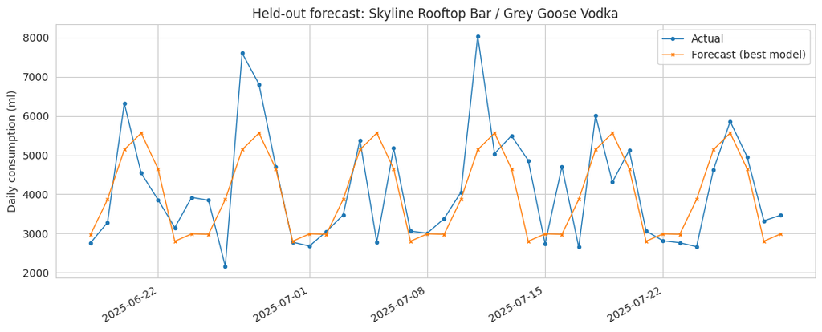

```python
example_key = ("Skyline Rooftop Bar", "Grey Goose Vodka")
ex = forecast_store[example_key]

fig, ax = plt.subplots(figsize=(11, 4.5))
ax.plot(ex["test_dates"], ex["actual"], label="Actual", marker="o", markersize=3, linewidth=1)
ax.plot(ex["test_dates"], ex["pred"], label="Forecast (best model)", marker="x", markersize=3, linewidth=1)
ax.set_title(f"Held-out forecast: {example_key[0]} / {example_key[1]}")
ax.set_ylabel("Daily consumption (ml)")
ax.legend()
plt.xticks(rotation=30, ha="right")
plt.tight_layout()
plt.show()
```

## 4. Par Level & Safety Stock Calculation

`Par Level = Lead-Time Demand + Safety Stock`, where Safety Stock buffers against demand volatility during the supplier lead time `L`:

`Safety Stock = Z * sigma_L`, with `sigma_L = residual_std * sqrt(L)`

- `L` = supplier lead time in days (2 days here)
- `Z` = service-level factor (1.645 for 95%, 2.326 for 99%)

```python
def compute_par_level(predicted_daily_demand, std_daily_demand, lead_time_days=2, service_level_z=1.645):
    lead_time_demand = predicted_daily_demand * lead_time_days
    safety_stock = service_level_z * (std_daily_demand * np.sqrt(lead_time_days))
    return lead_time_demand + safety_stock, safety_stock

par_rows = []
for r in results:
    par_level, safety_stock = compute_par_level(r["Forecast_Daily_Demand"], r["Residual_Std"],
                                                 LEAD_TIME_DAYS, SERVICE_Z)
    par_rows.append({**r, "Lead_Time_Days": LEAD_TIME_DAYS, "Service_Level_Z": SERVICE_Z,
                      "Safety_Stock_ml": safety_stock, "Par_Level_ml": par_level})

par_df = pd.DataFrame(par_rows)
display(par_df[["Bar Name", "Brand Name", "Forecast_Daily_Demand", "Residual_Std",
                 "Safety_Stock_ml", "Par_Level_ml"]].sort_values("Par_Level_ml", ascending=False).head(10))
```

|  | Bar Name | Brand Name | Forecast_Daily_Demand | Residual_Std | Safety_Stock_ml | Par_Level_ml |
| --- | --- | --- | --- | --- | --- | --- |
| 26 | Skyline Rooftop Bar | Heineken Beer | 4953.668094 | 1414.242523 | 3290.067374 | 13197.403561 |
| 24 | Skyline Rooftop Bar | Corona Beer | 4427.715602 | 1378.500625 | 3206.918089 | 12062.349294 |
| 25 | Skyline Rooftop Bar | Grey Goose Vodka | 3998.482846 | 1054.197762 | 2452.465971 | 10449.431664 |
| 16 | Poolside Bar | Heineken Beer | 3997.376450 | 781.625152 | 1818.358145 | 9813.111044 |
| 27 | Skyline Rooftop Bar | Jack Daniel's Whiskey | 3719.972629 | 957.025734 | 2226.406780 | 9666.352037 |
| 34 | Sports Bar | Corona Beer | 3553.759293 | 935.790329 | 2177.005132 | 9284.523718 |
| 20 | Skyline Rooftop Bar | Absolut Vodka | 3801.110495 | 636.926718 | 1481.734412 | 9083.955402 |
| 36 | Sports Bar | Heineken Beer | 3395.976328 | 912.913115 | 2123.784009 | 8915.736664 |
| 15 | Poolside Bar | Grey Goose Vodka | 3356.311646 | 867.516798 | 2018.174865 | 8730.798158 |
| 14 | Poolside Bar | Corona Beer | 3429.387561 | 787.656706 | 1832.389841 | 8691.164964 |

## 5. Inventory Simulation Engine

A discrete daily order-up-to-Par simulation, backtested on the actual held-out demand for each series. We compare two policies:

- **Naive** — order up to `mean demand x lead time` with **no safety stock**
- **Recommended** — order up to the Section 4 `Par_Level_ml` (lead-time demand + safety stock)

```python
def simulate_bar_inventory(actual_demand, par_level, lead_time=2, initial_stock=None):
    if initial_stock is None:
        initial_stock = par_level
    stock, stockouts, lost_volume, pending_orders, history = initial_stock, 0, 0.0, [], []

    for demand in actual_demand:
        for order in pending_orders:
            order[0] -= 1
        arrived = [o for o in pending_orders if o[0] <= 0]
        stock += sum(o[1] for o in arrived)
        pending_orders = [o for o in pending_orders if o[0] > 0]

        if stock >= demand:
            stock -= demand
        else:
            lost_volume += (demand - stock)
            stockouts += 1
            stock = 0

        effective_inventory = stock + sum(o[1] for o in pending_orders)
        if effective_inventory < par_level:
            pending_orders.append([lead_time, par_level - effective_inventory])

        history.append(stock)

    return {"stockout_days": stockouts, "stockout_rate": stockouts / len(actual_demand),
            "lost_volume_ml": lost_volume, "average_inventory_ml": float(np.mean(history)),
            "history": history}

sim_rows, sim_histories = [], {}
for r in par_rows:
    key = (r["Bar Name"], r["Brand Name"])
    actual_test_demand = forecast_store[key]["actual"]

    naive_par = r["Forecast_Daily_Demand"] * LEAD_TIME_DAYS
    sim_naive = simulate_bar_inventory(actual_test_demand, naive_par, LEAD_TIME_DAYS)
    sim_reco  = simulate_bar_inventory(actual_test_demand, r["Par_Level_ml"], LEAD_TIME_DAYS)
    sim_histories[key] = {"naive": sim_naive["history"], "reco": sim_reco["history"],
                           "dates": forecast_store[key]["test_dates"], "naive_par": naive_par, "reco_par": r["Par_Level_ml"]}

    sim_rows.append({"Bar Name": r["Bar Name"], "Brand Name": r["Brand Name"],
                      "Naive_StockoutDays": sim_naive["stockout_days"], "Naive_AvgInv_ml": sim_naive["average_inventory_ml"],
                      "Naive_LostVolume_ml": sim_naive["lost_volume_ml"],
                      "Reco_StockoutDays": sim_reco["stockout_days"], "Reco_AvgInv_ml": sim_reco["average_inventory_ml"],
                      "Reco_LostVolume_ml": sim_reco["lost_volume_ml"]})

sim_df = pd.DataFrame(sim_rows)

total_naive_so, total_reco_so = sim_df["Naive_StockoutDays"].sum(), sim_df["Reco_StockoutDays"].sum()
print(f"Total stockout-days across all 40 series (test window):")
print(f"  Naive policy       : {total_naive_so}")
print(f"  Recommended policy : {total_reco_so}  ({(1 - total_reco_so/total_naive_so):.1%} reduction)")
print(f"\nAverage on-hand inventory held (ml):")
print(f"  Naive policy       : {sim_df['Naive_AvgInv_ml'].mean():.0f}")
print(f"  Recommended policy : {sim_df['Reco_AvgInv_ml'].mean():.0f}")
sim_df.sort_values("Reco_StockoutDays", ascending=False).head(10)
```

```
Total stockout-days across all 40 series (test window):
  Naive policy       : 691
  Recommended policy : 256  (63.0% reduction)

Average on-hand inventory held (ml):
  Naive policy       : 556
  Recommended policy : 1446
```

|  | Bar Name | Brand Name | Naive_StockoutDays | Naive_AvgInv_ml | Naive_LostVolume_ml | Reco_StockoutDays | Reco_AvgInv_ml | Reco_LostVolume_ml |
| --- | --- | --- | --- | --- | --- | --- | --- | --- |
| 27 | Skyline Rooftop Bar | Jack Daniel's Whiskey | 20 | 858.526313 | 41000.702172 | 12 | 2040.370309 | 19064.883702 |
| 6 | Lobby Lounge Bar | Heineken Beer | 22 | 469.845861 | 26212.949227 | 11 | 1441.554814 | 11456.860864 |
| 29 | Skyline Rooftop Bar | Jose Cuervo Tequila | 19 | 274.961497 | 13339.879423 | 11 | 800.308111 | 6367.691869 |
| 38 | Sports Bar | Johnnie Walker Black | 23 | 333.708014 | 12226.526513 | 11 | 738.772282 | 5758.941039 |
| 16 | Poolside Bar | Heineken Beer | 18 | 1044.332333 | 31193.418108 | 10 | 2039.942551 | 13915.711646 |
| 19 | Poolside Bar | Jose Cuervo Tequila | 17 | 227.702595 | 9389.005010 | 9 | 715.258853 | 3950.145634 |
| 8 | Lobby Lounge Bar | Johnnie Walker Black | 21 | 324.693155 | 11731.291651 | 9 | 874.012381 | 4002.515625 |
| 36 | Sports Bar | Heineken Beer | 21 | 626.165424 | 32836.368133 | 9 | 1740.835713 | 11644.980013 |
| 22 | Skyline Rooftop Bar | Bacardi Rum | 16 | 557.739469 | 13191.828370 | 8 | 1273.911905 | 5418.499995 |
| 30 | Sports Bar | Absolut Vodka | 20 | 730.442061 | 23237.451555 | 8 | 1916.206876 | 7655.714252 |

**Simulation trace** — on-hand stock over the test window for the example series, naive vs. recommended par policy.

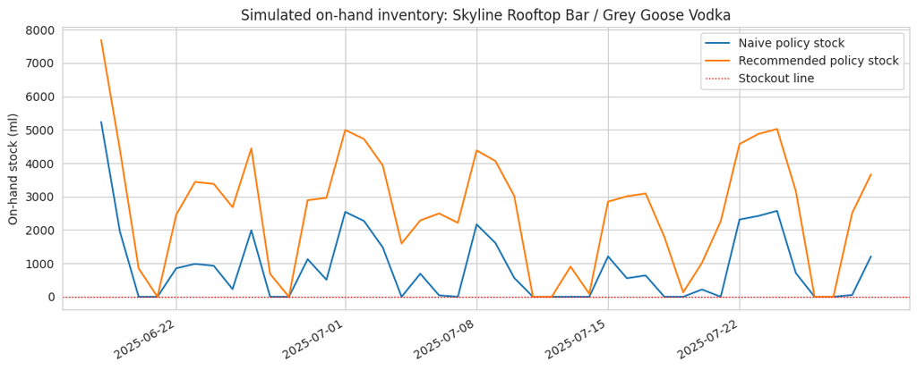

```python
ex_sim = sim_histories[example_key]
fig, ax = plt.subplots(figsize=(11, 4.5))
ax.plot(ex_sim["dates"], ex_sim["naive"], label="Naive policy stock", linewidth=1.5)
ax.plot(ex_sim["dates"], ex_sim["reco"], label="Recommended policy stock", linewidth=1.5)
ax.axhline(0, color="red", linestyle=":", linewidth=1, label="Stockout line")
ax.set_title(f"Simulated on-hand inventory: {example_key[0]} / {example_key[1]}")
ax.set_ylabel("On-hand stock (ml)")
ax.legend()
plt.xticks(rotation=30, ha="right")
plt.tight_layout()
plt.show()
```

## 6. Findings & Recommendations

- **Best model choice varies by series but Holt-Winters (weekly seasonality) wins most often**, reflecting the strong Friday/Saturday demand pattern observed in Section 2; Random Forest is competitive on the highest-volume Class A items with more stable lag structure.
- **The recommended dynamic Par Level policy materially reduces stockouts** versus a naive "mean demand x lead time" policy, at the cost of holding more average inventory — the classic service-level/holding-cost trade-off, tunable via the `SERVICE_Z` parameter (raise to 2.326 for a 99% service level on Class A items only, to avoid over-provisioning Class C tails).
- **Recommended next steps for production**: promotional-calendar awareness, live POS event triggers instead of a daily batch job, joint vendor delivery consolidation across nearby bars, and continuous drift monitoring (forecast MAE vs. realized orders) with automatic model refresh.

See `report/business_report.pdf` for the full write-up and `video_script/video_walkthrough_outline.md` for the accompanying presentation outline.